# Exploratory Data Analysis For Global Martenal,Neonatal & Child Deaths Between 2000 and 2019

Gift mtambo

2/14/2022

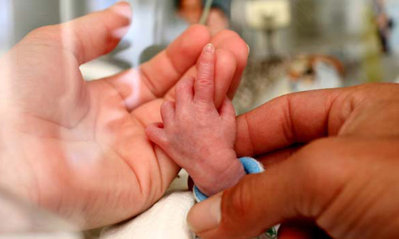

### 1.0 INTRODUCTION

- Improvements have been made worldwide in reducing maternal and child morbidities and mortalities. However, rates are still high. According to the World Health Organization (WHO), approximately 810 women died from preventable causes of pregnancy and childbirth every day in 2017 (WHO, 2019).
- Maternal mortality rates for most countries result from complex socio-economic forces including a lack of access to skilled care during pregnancy and childbirth and lack of access to safe abortions, even where legal. Poverty, low status of women, lack of education, poor nutrition, heavy workloads and violence are all risk factors of poor outcomes for pregnant women.
- To further explore those rates and form insights on the maternal and child health situation worldwide, we will analyze data from the World Bank Indicators (WBI) on maternal, neonatal and infant mortality.
  - **Maternal Mortality Ratio (MMR)** : number of women who die from pregnancy-related causes while pregnant or within 42 days of pregnancy termination per 100,000 live births.
  - **Neonatal Mortality Rate (NMR)** : the number of neonates dying before reaching 28 days of age, per 1,000 live births in a given year.
  - **Infant Mortality Rate (IMR)** : number of infants dying before reaching one year of age, per 1,000 live births in a given year.

### 2.Loading and Checking the dataset:

```r
# Load the packgaes
library(readr) # reading
library(plyr)
library(dplyr) # manipulating data
library(tidyr) # pivoting data and dropping missing values
library(janitor) # cleaning column names
library(ggplot2) # plotting data
library(tidyverse)
library(ggthemes) # adding themes to plots
library(WDI)
```

## Download and load the dataset

```r
raw_data<- WDI(country="all",
              indicator = c("Mortality_rate_neonatal"="SH.DYN.NMRT",
                         "Maternal_mortality_ratio"="SH.STA.MMRT",
                         "Mortality_rate_infant"="SP.DYN.IMRT.IN",
                         "Mortality_rate_infant_male" ="SP.DYN.IMRT.MA.IN",
                "Mortality_rate_infant_female"="SP.DYN.IMRT.FE.IN"),   start=2000,end=2020,extra = TRUE)
```

```r
write.table(raw_data, file = "WDI.csv", sep = ",", col.names = NA,
            qmethod = "double")
```

```r
# define the filename
filename <- "WDI.csv"
# load the CSV file from the local directory
raw_data<- read.csv(filename,header=T,sep=",")
```

```r
#display the data
head(raw_data,n=5)
```

```
  X iso2c    country year status Mortality_rate_neonatal
1 1    1A Arab World 2000     NA                25.43366
2 2    1A Arab World 2001     NA                24.93282
3 3    1A Arab World 2004     NA                23.37480
4 4    1A Arab World 2005     NA                22.81931
5 5    1A Arab World 2002     NA                24.44103
  Maternal_mortality_ratio Mortality_rate_infant Mortality_rate_infant_male
1                      250              44.09257                   47.61277
2                      243              42.80036                   46.24128
3                      226              39.03268                   42.17217
4                      214              37.82395                   40.86584
5                      235              41.50109                   44.89622
  Mortality_rate_infant_female iso3c     region capital longitude latitude
1                     40.37474   ARB Aggregates                NA       NA
2                     39.16552   ARB Aggregates                NA       NA
3                     35.73251   ARB Aggregates                NA       NA
4                     34.61242   ARB Aggregates                NA       NA
5                     37.94841   ARB Aggregates                NA       NA
      income    lending
1 Aggregates Aggregates
2 Aggregates Aggregates
3 Aggregates Aggregates
4 Aggregates Aggregates
5 Aggregates Aggregates
```

```r
# display the column names
names(raw_data)
```

```
 [1] "X"                            "iso2c"
 [3] "country"                      "year"
 [5] "status"                       "Mortality_rate_neonatal"
 [7] "Maternal_mortality_ratio"     "Mortality_rate_infant"
 [9] "Mortality_rate_infant_male"   "Mortality_rate_infant_female"
[11] "iso3c"                        "region"
[13] "capital"                      "longitude"
[15] "latitude"                     "income"
[17] "lending"
```

```r
#list types for each attribute
sapply(raw_data, class)
```

```
                           X                        iso2c
                   "integer"                  "character"
                     country                         year
                 "character"                    "integer"
                      status      Mortality_rate_neonatal
                   "logical"                    "numeric"
    Maternal_mortality_ratio        Mortality_rate_infant
                   "integer"                    "numeric"
  Mortality_rate_infant_male Mortality_rate_infant_female
                   "numeric"                    "numeric"
                       iso3c                       region
                 "character"                  "character"
                     capital                    longitude
                 "character"                    "numeric"
                    latitude                       income
                   "numeric"                  "character"
                     lending
                 "character"
```

### 3.Data Cleaning And Analysis:

```r
#remove the unncessary rows
df<-raw_data[ grep("Aggregates", raw_data$region, invert = TRUE) , ]

head(df,n=5)
```

```
      X iso2c country year status Mortality_rate_neonatal
106 106    AD Andorra 2006     NA                     2.7
107 107    AD Andorra 2002     NA                     3.3
108 108    AD Andorra 2003     NA                     3.2
109 109    AD Andorra 2005     NA                     2.9
110 110    AD Andorra 2019     NA                     1.4
    Maternal_mortality_ratio Mortality_rate_infant Mortality_rate_infant_male
106                       NA                   5.3                        5.8
107                       NA                   6.5                        7.2
108                       NA                   6.2                        6.9
109                       NA                   5.6                        6.2
110                       NA                   2.5                        2.7
    Mortality_rate_infant_female iso3c                region          capital
106                          4.7   AND Europe & Central Asia Andorra la Vella
107                          5.8   AND Europe & Central Asia Andorra la Vella
108                          5.5   AND Europe & Central Asia Andorra la Vella
109                          4.9   AND Europe & Central Asia Andorra la Vella
110                          2.2   AND Europe & Central Asia Andorra la Vella
    longitude latitude      income        lending
106    1.5218  42.5075 High income Not classified
107    1.5218  42.5075 High income Not classified
108    1.5218  42.5075 High income Not classified
109    1.5218  42.5075 High income Not classified
110    1.5218  42.5075 High income Not classified
```

```r
#select all the indicators and put them into a new column
df1 <- df%>%
   pivot_longer(
    cols = c("Mortality_rate_neonatal","Maternal_mortality_ratio",
             "Mortality_rate_infant","Mortality_rate_infant_male","Mortality_rate_infant_female"),
  names_to = "indicator", values_to = "value")%>%
  #select the neccessary columns
  select("country","year", "indicator","value","region","longitude","latitude" )%>%
  arrange(country,indicator,year)

head(df1,n=17)
```

```
# A tibble: 17 x 7
   country      year indicator                value region    longitude latitude
   <chr>       <int> <chr>                    <dbl> <chr>         <dbl>    <dbl>
 1 Afghanistan  2000 Maternal_mortality_ratio  1450 South As~      69.2     34.5
 2 Afghanistan  2001 Maternal_mortality_ratio  1390 South As~      69.2     34.5
 3 Afghanistan  2002 Maternal_mortality_ratio  1300 South As~      69.2     34.5
 4 Afghanistan  2003 Maternal_mortality_ratio  1240 South As~      69.2     34.5
 5 Afghanistan  2004 Maternal_mortality_ratio  1180 South As~      69.2     34.5
 6 Afghanistan  2005 Maternal_mortality_ratio  1140 South As~      69.2     34.5
 7 Afghanistan  2006 Maternal_mortality_ratio  1120 South As~      69.2     34.5
 8 Afghanistan  2007 Maternal_mortality_ratio  1090 South As~      69.2     34.5
 9 Afghanistan  2008 Maternal_mortality_ratio  1030 South As~      69.2     34.5
10 Afghanistan  2009 Maternal_mortality_ratio   993 South As~      69.2     34.5
11 Afghanistan  2010 Maternal_mortality_ratio   954 South As~      69.2     34.5
12 Afghanistan  2011 Maternal_mortality_ratio   905 South As~      69.2     34.5
13 Afghanistan  2012 Maternal_mortality_ratio   858 South As~      69.2     34.5
14 Afghanistan  2013 Maternal_mortality_ratio   810 South As~      69.2     34.5
15 Afghanistan  2014 Maternal_mortality_ratio   786 South As~      69.2     34.5
16 Afghanistan  2015 Maternal_mortality_ratio   701 South As~      69.2     34.5
17 Afghanistan  2016 Maternal_mortality_ratio   673 South As~      69.2     34.5
```

```r
# checking unique indicators
unique(df1[c("indicator")])
```

```
# A tibble: 5 x 1
  indicator
  <chr>
1 Maternal_mortality_ratio
2 Mortality_rate_infant
3 Mortality_rate_infant_female
4 Mortality_rate_infant_male
5 Mortality_rate_neonatal
```

```r
#checking for unique regions
unique(df1[c("region")])
```

```
# A tibble: 8 x 1
  region
  <chr>
1 South Asia
2 Europe & Central Asia
3 Middle East & North Africa
4 East Asia & Pacific
5 Sub-Saharan Africa
6 Latin America & Caribbean
7 North America
8 <NA>
```

#### Creating a data frame with the Mean of each region

```r
# compute yearly means by regions and create data frame
region_mortality <- df1 %>%
  group_by(year, indicator, region) %>%
  drop_na() %>%
  summarise(mean_mortality = mean(value))
head(region_mortality)
```

```
# A tibble: 6 x 4
# Groups:   year, indicator [1]
   year indicator                region                     mean_mortality
  <int> <chr>                    <chr>                               <dbl>
1  2000 Maternal_mortality_ratio East Asia & Pacific                 164.
2  2000 Maternal_mortality_ratio Europe & Central Asia                21.2
3  2000 Maternal_mortality_ratio Latin America & Caribbean           110.
4  2000 Maternal_mortality_ratio Middle East & North Africa           86.2
5  2000 Maternal_mortality_ratio North America                        10.5
6  2000 Maternal_mortality_ratio South Asia                          462.
```

#### Creating a data frame with the Mean of each year

```r
# compute yearly means and create data frame
world_mortality <- df1 %>%
  group_by(year, indicator) %>%
  drop_na() %>%
  summarise(mean_mortality = mean(value))
tail(world_mortality)
```

```
# A tibble: 6 x 3
# Groups:   year [2]
   year indicator                    mean_mortality
  <int> <chr>                                 <dbl>
1  2019 Mortality_rate_infant_male             23.0
2  2019 Mortality_rate_neonatal                12.7
3  2020 Mortality_rate_infant                  20.4
4  2020 Mortality_rate_infant_female           18.4
5  2020 Mortality_rate_infant_male             22.4
6  2020 Mortality_rate_neonatal                12.4
```

### Summary Statistics

#### Yearly mean mortality

```r
df1 %>%
  group_by(year, indicator) %>%
  drop_na() %>%
  summarise(mean = mean(value)) %>%
  pivot_wider(names_from = indicator, values_from = mean)
```

```
# A tibble: 21 x 6
# Groups:   year [21]
    year Maternal_mortali~ Mortality_rate_i~ Mortality_rate_i~ Mortality_rate_i~
   <int>             <dbl>             <dbl>             <dbl>             <dbl>
 1  2000              276.              38.5              35.0              41.8
 2  2001              267.              37.1              33.7              40.3
 3  2002              260.              35.8              32.5              38.9
 4  2003              252.              34.5              31.3              37.5
 5  2004              242.              33.3              30.2              36.3
 6  2005              231.              32.1              29.0              34.9
 7  2006              222.              30.9              28.0              33.7
 8  2007              213.              29.9              27.0              32.6
 9  2008              206.              29.0              26.2              31.6
10  2009              199.              28.0              25.3              30.6
# ... with 11 more rows, and 1 more variable: Mortality_rate_neonatal <dbl>
```

```r
  #rename(replace=c(mean_mmr= "Mortality rate,neonatal",
                    #"mean_nmmr"="Martenal mortality ratio",
                    #"mean_imr"="Mortality rate,infant",
                    ##"mean_imr_m"="Mortality rate,infant,male",
                    #"mean_imr_f"="Mortality rate,infant,female")
  #),warn_missing = FALSE)
```

#### Yearly mean mortality per region

```r
df1 %>%
  group_by(year, indicator, region) %>%
  drop_na() %>%
  summarise(mean = mean(value)) %>%
  pivot_wider(names_from = indicator, values_from = mean)
```

```
# A tibble: 147 x 7
# Groups:   year [21]
    year region        Maternal_mortality~ Mortality_rate_i~ Mortality_rate_inf~
   <int> <chr>                       <dbl>             <dbl>               <dbl>
 1  2000 East Asia & ~               164.               31.5                28.3
 2  2000 Europe & Cen~                21.2              14.7                13.0
 3  2000 Latin Americ~               110.               24.2                21.7
 4  2000 Middle East ~                86.2              26.2                24.1
 5  2000 North America                10.5               6.2                 5.6
 6  2000 South Asia                  462.               58.4                54.7
 7  2000 Sub-Saharan ~               759.               80.9                74.1
 8  2001 East Asia & ~               158.               30.3                27.2
 9  2001 Europe & Cen~                20.2              13.9                12.3
10  2001 Latin Americ~               108.               23.5                21.0
# ... with 137 more rows, and 2 more variables:
#   Mortality_rate_infant_male <dbl>, Mortality_rate_neonatal <dbl>
```

#### The country with the lowest maternal mortality ratio by year

```r
df1 %>%
  filter(indicator == "Maternal_mortality_ratio") %>%
  select(year, country,region, value) %>%
  drop_na() %>%
  arrange(value) %>%
  group_by(year) %>%
    slice(1:1) %>%
    print(n=21)
```

```
# A tibble: 18 x 4
# Groups:   year [18]
    year country region                value
   <int> <chr>   <chr>                 <dbl>
 1  2000 Greece  Europe & Central Asia     3
 2  2001 Greece  Europe & Central Asia     3
 3  2002 Greece  Europe & Central Asia     3
 4  2003 Greece  Europe & Central Asia     3
 5  2004 Greece  Europe & Central Asia     3
 6  2005 Greece  Europe & Central Asia     3
 7  2006 Italy   Europe & Central Asia     2
 8  2007 Italy   Europe & Central Asia     2
 9  2008 Italy   Europe & Central Asia     2
10  2009 Italy   Europe & Central Asia     2
11  2010 Italy   Europe & Central Asia     2
12  2011 Italy   Europe & Central Asia     2
13  2012 Italy   Europe & Central Asia     2
14  2013 Italy   Europe & Central Asia     2
15  2014 Italy   Europe & Central Asia     2
16  2015 Italy   Europe & Central Asia     2
17  2016 Italy   Europe & Central Asia     2
18  2017 Belarus Europe & Central Asia     2
```

**Observations**

- The country with the lowest yearly maternal mortality ratio has consistently been from the Europe and Central Asia region (Greece, Italy, and Belarus)

#### The country with the highest maternal mortality ratio by year

```r
df1 %>%
  filter(indicator == "Maternal_mortality_ratio") %>%
  select(year, country,region, value) %>%
  drop_na() %>%
  arrange(desc(value)) %>%
  group_by(year) %>%
    slice(1:1) %>%
    print(n=21)
```

```
# A tibble: 18 x 4
# Groups:   year [18]
    year country      region             value
   <int> <chr>        <chr>              <dbl>
 1  2000 Sierra Leone Sub-Saharan Africa  2480
 2  2001 Sierra Leone Sub-Saharan Africa  2250
 3  2002 Sierra Leone Sub-Saharan Africa  2080
 4  2003 Sierra Leone Sub-Saharan Africa  1960
 5  2004 Sierra Leone Sub-Saharan Africa  1850
 6  2005 Sierra Leone Sub-Saharan Africa  1760
 7  2006 Sierra Leone Sub-Saharan Africa  1680
 8  2007 Sierra Leone Sub-Saharan Africa  1610
 9  2008 Sierra Leone Sub-Saharan Africa  1530
10  2009 Sierra Leone Sub-Saharan Africa  1450
11  2010 Sierra Leone Sub-Saharan Africa  1360
12  2011 Sierra Leone Sub-Saharan Africa  1270
13  2012 Sierra Leone Sub-Saharan Africa  1210
14  2013 Sierra Leone Sub-Saharan Africa  1180
15  2014 Sierra Leone Sub-Saharan Africa  1190
16  2015 Sierra Leone Sub-Saharan Africa  1180
17  2016 Chad         Sub-Saharan Africa  1140
18  2017 South Sudan  Sub-Saharan Africa  1150
```

**Observations**

-The country with the highest yearly maternal mortality ratio has consistently been from the Sub-Saharan Africa region (Sierra Leone, Chad, and South Sudan).

#### The country with the lowest neonatal mortality rate by year

```r
df1 %>%
  filter(indicator == "Mortality_rate_neonatal") %>%
  select(year, country,region, value) %>%
  drop_na() %>%
  arrange(value) %>%
  group_by(year) %>%
    slice(1:1) %>%
    print(n=21)
```

```
# A tibble: 21 x 4
# Groups:   year [21]
    year country    region                value
   <int> <chr>      <chr>                 <dbl>
 1  2000 Singapore  East Asia & Pacific     1.6
 2  2001 Singapore  East Asia & Pacific     1.5
 3  2002 Singapore  East Asia & Pacific     1.4
 4  2003 Singapore  East Asia & Pacific     1.3
 5  2004 Singapore  East Asia & Pacific     1.3
 6  2005 Singapore  East Asia & Pacific     1.2
 7  2006 Singapore  East Asia & Pacific     1.2
 8  2007 Singapore  East Asia & Pacific     1.2
 9  2008 Japan      East Asia & Pacific     1.2
10  2009 Japan      East Asia & Pacific     1.2
11  2010 Japan      East Asia & Pacific     1.1
12  2011 Japan      East Asia & Pacific     1
13  2012 Japan      East Asia & Pacific     1
14  2013 Japan      East Asia & Pacific     1
15  2014 Japan      East Asia & Pacific     0.9
16  2015 Japan      East Asia & Pacific     0.9
17  2016 Japan      East Asia & Pacific     0.9
18  2017 Japan      East Asia & Pacific     0.9
19  2018 Japan      East Asia & Pacific     0.9
20  2019 San Marino Europe & Central Asia   0.8
21  2020 Japan      East Asia & Pacific     0.8
```

**Observations**

#### The country with the highest neonatal mortality rate by year

```r
df1 %>%
  filter(indicator == "Mortality_rate_neonatal") %>%
  select(year, country,region, value) %>%
  drop_na() %>%
  arrange(desc(value)) %>%
  group_by(year) %>%
    slice(1:1) %>%
    print(n=21)
```

```
# A tibble: 21 x 4
# Groups:   year [21]
    year country     region             value
   <int> <chr>       <chr>              <dbl>
 1  2000 Afghanistan South Asia          60.9
 2  2001 Afghanistan South Asia          59.7
 3  2002 Afghanistan South Asia          58.5
 4  2003 Afghanistan South Asia          57.2
 5  2004 Afghanistan South Asia          55.9
 6  2005 Afghanistan South Asia          54.6
 7  2006 Afghanistan South Asia          53.2
 8  2007 Afghanistan South Asia          51.7
 9  2008 Pakistan    South Asia          50.9
10  2009 Pakistan    South Asia          50.4
11  2010 Pakistan    South Asia          49.8
12  2011 Pakistan    South Asia          49
13  2012 Pakistan    South Asia          48.1
14  2013 Pakistan    South Asia          47.1
15  2014 Pakistan    South Asia          46.2
16  2015 Pakistan    South Asia          45.2
17  2016 Lesotho     Sub-Saharan Africa  45.1
18  2017 Lesotho     Sub-Saharan Africa  45.2
19  2018 Lesotho     Sub-Saharan Africa  45.1
20  2019 Lesotho     Sub-Saharan Africa  44.8
21  2020 Lesotho     Sub-Saharan Africa  44.3
```

**Observations**

- The country with the highest yearly neonatal mortality rate (nmr) has mostly come from South Asia (Afghanistan and Pakistan) and Sub Saharan Africa (Lesotho).

#### The country with the lowest infant mortality rate by year

```r
df1 %>%
  filter(indicator == "Mortality_rate_infant") %>%
  select(year, country,region, value) %>%
  drop_na() %>%
  arrange(value) %>%
  group_by(year) %>%
    slice(1:1) %>%
    print(n=21)
```

```
# A tibble: 21 x 4
# Groups:   year [21]
    year country   region                value
   <int> <chr>     <chr>                 <dbl>
 1  2000 Singapore East Asia & Pacific     3
 2  2001 Singapore East Asia & Pacific     2.8
 3  2002 Singapore East Asia & Pacific     2.6
 4  2003 Singapore East Asia & Pacific     2.5
 5  2004 Singapore East Asia & Pacific     2.4
 6  2005 Singapore East Asia & Pacific     2.3
 7  2006 Singapore East Asia & Pacific     2.3
 8  2007 Singapore East Asia & Pacific     2.3
 9  2008 Iceland   Europe & Central Asia   2.3
10  2009 Iceland   Europe & Central Asia   2.2
11  2010 Iceland   Europe & Central Asia   2.2
12  2011 Iceland   Europe & Central Asia   2.1
13  2012 Iceland   Europe & Central Asia   2
14  2013 Iceland   Europe & Central Asia   1.9
15  2014 Iceland   Europe & Central Asia   1.9
16  2015 Iceland   Europe & Central Asia   1.8
17  2016 Iceland   Europe & Central Asia   1.8
18  2017 Iceland   Europe & Central Asia   1.7
19  2018 Iceland   Europe & Central Asia   1.6
20  2019 Iceland   Europe & Central Asia   1.6
21  2020 Iceland   Europe & Central Asia   1.5
```

**Observations**

#### The country with the highest infant mortality rate by year

```r
df1 %>%
  filter(indicator == "Mortality_rate_infant") %>%
  select(year, country,region, value) %>%
  drop_na() %>%
  arrange(desc(value)) %>%
  group_by(year) %>%
    slice(1:1) %>%
    print(n=21)
```

```
# A tibble: 21 x 4
# Groups:   year [21]
    year country      region             value
   <int> <chr>        <chr>              <dbl>
 1  2000 Sierra Leone Sub-Saharan Africa 138.
 2  2001 Sierra Leone Sub-Saharan Africa 136.
 3  2002 Sierra Leone Sub-Saharan Africa 133.
 4  2003 Sierra Leone Sub-Saharan Africa 130.
 5  2004 Sierra Leone Sub-Saharan Africa 127.
 6  2005 Sierra Leone Sub-Saharan Africa 124.
 7  2006 Sierra Leone Sub-Saharan Africa 121.
 8  2007 Sierra Leone Sub-Saharan Africa 118.
 9  2008 Sierra Leone Sub-Saharan Africa 114.
10  2009 Sierra Leone Sub-Saharan Africa 111.
11  2010 Sierra Leone Sub-Saharan Africa 107.
12  2011 Sierra Leone Sub-Saharan Africa 104.
13  2012 Sierra Leone Sub-Saharan Africa 101.
14  2013 Sierra Leone Sub-Saharan Africa  97.7
15  2014 Sierra Leone Sub-Saharan Africa  95.6
16  2015 Sierra Leone Sub-Saharan Africa  95.1
17  2016 Sierra Leone Sub-Saharan Africa  89.7
18  2017 Sierra Leone Sub-Saharan Africa  87.3
19  2018 Sierra Leone Sub-Saharan Africa  84.8
20  2019 Sierra Leone Sub-Saharan Africa  82.4
21  2020 Sierra Leone Sub-Saharan Africa  80.1
```

**Observations**

#### Data Visualisation

```r
my_theme <- function() {
  theme(
    text = element_text(family = "Comic Sans MS"),
    panel.border = element_rect(linetype = "dashed", fill= NA, color = "black"),
    panel.background = element_rect(fill = "#f0f0f0"),
    panel.grid.major = element_line(color = "white"),
    plot.title = element_text(size = rel(1)),
    plot.background = element_blank(),
    axis.title = element_text(size = 8),
    legend.title = element_blank(),
    legend.background = element_blank(),
    legend.position = "bottom",
    legend.text = element_text(size = 8),
    plot.subtitle = element_text(size = rel(0.8), color = "#f03b20")
        )
}
```

#### Yearly Mean Maternal Mortality Ratio per region

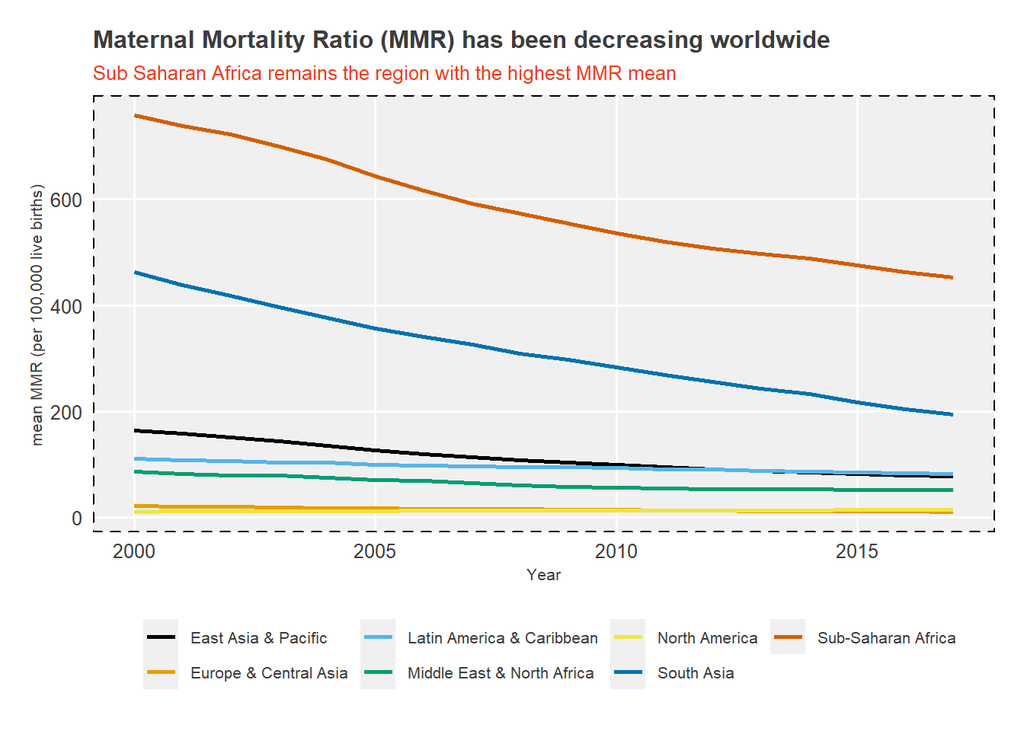

```r
region_mortality%>%
  filter(indicator == "Maternal_mortality_ratio") %>%
  ggplot( aes(x=year, y= mean_mortality, color=region)) +
  geom_line(size = 1) +
  scale_color_colorblind() +
  scale_x_continuous(breaks = seq(2000,2020,5)) +
  labs(x="Year",
       y="mean MMR (per 100,000 live births) ",
       title="Maternal Mortality Ratio (MMR) has been decreasing worldwide ",
       subtitle = "Sub Saharan Africa remains the region with the highest MMR mean")+
  theme_fivethirtyeight() +
  my_theme()
```

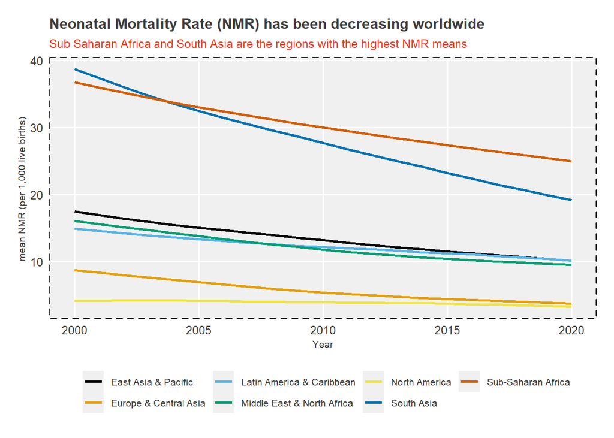

```r
region_mortality %>%
  filter(indicator == "Mortality_rate_neonatal") %>%
  ggplot( aes(x=year, y= mean_mortality, color=region)) +
  geom_line(size = 1) +
  scale_color_colorblind() +
  scale_x_continuous(breaks = seq(2000,2020,5)) +
  labs(x="Year",
       y="mean NMR (per 1,000 live births) ",
       title="Neonatal Mortality Rate (NMR) has been decreasing worldwide ",
       subtitle = "Sub Saharan Africa and South Asia are the regions with the highest NMR means",
      ) +
  theme_fivethirtyeight() +
  my_theme()
```

**Observations**

- Sub Saharan Africa and South Asia had the highest mean neonatal mortality rates while Europe and Central Asia and North America had the lowest.

#### Yearly Mean Infant Mortality Rate per region

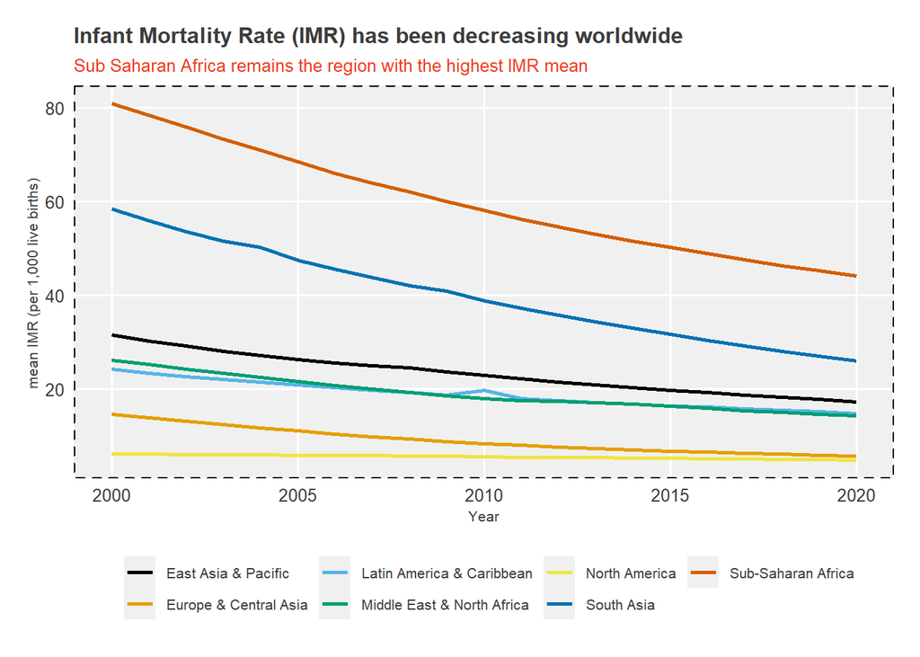

```r
region_mortality %>%
  filter(indicator == "Mortality_rate_infant") %>%
  ggplot( aes(x=year, y= mean_mortality, color=region)) +
  geom_line(size = 1) +
  scale_color_colorblind() +
  scale_x_continuous(breaks = seq(2000,2020,5)) +
  labs(x="Year",
       y="mean IMR (per 1,000 live births) ",
       title="Infant Mortality Rate (IMR) has been decreasing worldwide  ",
       subtitle = "Sub Saharan Africa remains the region with the highest IMR mean",
       ) +
  theme_fivethirtyeight() +
  my_theme()
```

**Observations**

- Sub Saharan Africa had the highest mean infant mortality rates, followed by South Asia while Europe and Central Asia and North America had the lowest.

#### Yearly Mean Infant Mortality Rate by sex and region

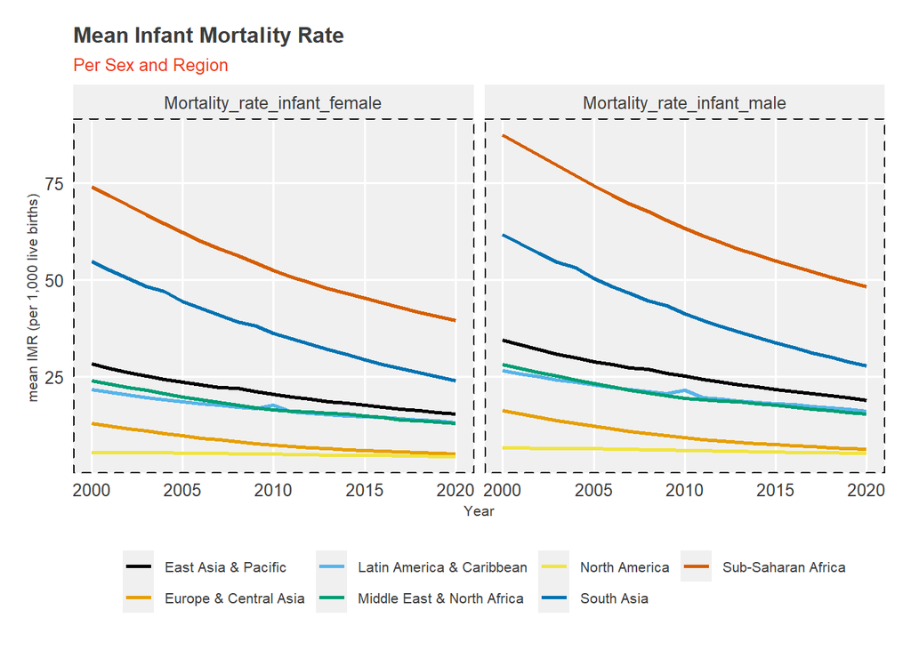

```r
imr_sex <- c("Mortality_rate_infant_male", "Mortality_rate_infant_female")
region_mortality %>%
  filter(indicator %in% imr_sex) %>%
  ggplot( aes(x=year, y= mean_mortality, color=region)) +
  geom_line(size =1) +
  facet_wrap(~indicator) +
  scale_color_colorblind() +
  scale_x_continuous(breaks = seq(2000,2020,5)) +
  labs(x="Year",
       y="mean IMR (per 1,000 live births) ",
       title="Mean Infant Mortality Rate ",
       subtitle = "Per Sex and Region",
       ) +
  theme_fivethirtyeight() +
  my_theme()
```

#### Yearly Mean Infant Mortality Rate by sex

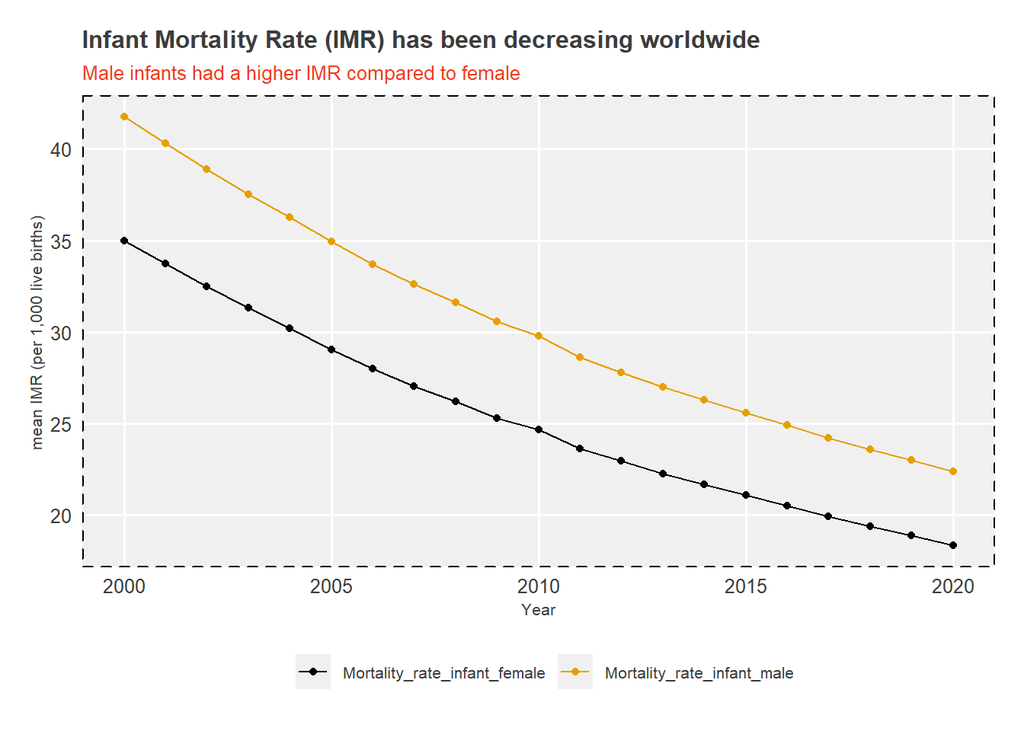

```r
world_mortality %>%
  filter(indicator %in% imr_sex) %>%
  ggplot( aes(x=year, y= mean_mortality, color=indicator)) +
  geom_point() +
  geom_line() +
  scale_color_colorblind() +
  scale_x_continuous(breaks = seq(2000,2020,5)) +
  labs(x="Year",
       y="mean IMR (per 1,000 live births) ",
       title="Infant Mortality Rate (IMR) has been decreasing worldwide ",
       subtitle = "Male infants had a higher IMR compared to female",
       ) +
  theme_fivethirtyeight() +
  my_theme()
```

**Takeways**

- Maternal Mortality Ratio(MMR), Neonatal Mortality Rate (NMR), and Infant Mortality Rate (IMR) has been decreasing worldwide.
- Sub Saharan Africa and South Asia are the two regions with the highest means for MMR, NMR and IMR.
- North America and Europe and Central Asia are the two regions with the lowest means for MMR, NMR and IMR.
- When comparing the IMR for the sexes, male infants have higher average means worldwide.